# QTLseq Method of Bulk Segregant Analysis

Cassandra Buzby

05 April, 2022

Keep in mind, use coolors.co for color palettes :)

Notes from Grace: use repeatmasker (isb), or trim off telomeres * institute for systems biology, seattle * probably also stops the transposons * there could also be variants

## Dataset:

```r
#rawData = "Data\\TEST2_MergedBQSR.output.table"
rawData = "Data\\TelTrimmed_mergedCuSO4.REF.SortedCat.vcf.output.table"
```

### Functions for running analysis and plots on all samples

Three functions (two below) complete the analysis uniformly between each pair of bulks. I’ve defined the min and max depths, in sample depth, and min genome quality at the top, and then used these arguments in `PipelineFunc` which analyzes the data using QTLseqR functions `filterSNPs()` , `runGprimeAnalysis` , and `runQTLseqAnalysis`. I have also adjustd `plotQTLStatsCB()` from QTLSeqR’s function `plotQTLStats()` to remove errors in not having enough points to create a threshold, since this was sometimes present in a single chromosome and then prevented the remaining chromosomes from being analyzed. Now that more data is passing the filters, I will likely change this back.

The last function is `plotallfunc()`, in which I input the output dataframe (filtered and analyzed) by `PipelineFunc()` to several plots, some of which are built into QTLSeqR and some of which I have created myself to better separate the data. Both functions are printed below, and each is then used on all samples (hidden) to produce the plots below.

```r
#################################################
#Change this to analyze all differently
#################################################

mindepth = 50
maxdepth = 1500
minsampledepth = 50
mingq = 0.98

PipelineFunc <- function(HighBulk, LowBulk, rawData,
                         mindepth = mindepth,
                         maxdepth = maxdepth,
                         minsampledepth = minsampledepth,
                         mingq = mingq,
                         windowSize = 3e4, #5e4 works
                         Chroms = c("NC_001134.8", "NC_001135.5", "NC_001136.10",
                                 "NC_001137.3", "NC_001138.5", "NC_001139.9", "NC_001140.6",
                                 "NC_001141.2", "NC_001142.9", "NC_001143.9", "NC_001144.5",
                                 "NC_001145.3", "NC_001146.8", "NC_001147.6", "NC_001148.4"),
                         BulkSize = 1000
                         ){

  mytitle <- paste(HighBulk, LowBulk, sep = " vs ")
  HNGLCDRXY <- read.table(rawData, header = TRUE)

  df <- importFromGATK(
        file = rawData,
        highBulk = HighBulk,
        lowBulk = LowBulk,
        chromList = Chroms #"NC_001133.9" #
        )

df %>% merge(.,ChromKey) %>%
  #group_by(CHROM) %>% mutate(Start = min(POS) + 350, End = max(POS) - 350) %>%
  as.data.frame() %>% na.omit() -> df

colnames(df)[1] <- "NC_Chrom"
colnames(df)[which(colnames(df) == "chromosomes")] <- "CHROM"

df$CHROM <- factor(df$CHROM, levels = c("I", "II", "III", "IV", "V", "VI", "VII", "VIII", "IX", "X", "XI", "XII", "XIII", "XIV", "XV", "XVI", "M"))
#################################

#Filter SNPs based on some criteria
df_filt <-
    filterSNPs(
        SNPset = df,
        refAlleleFreq = 0.10, #0.20
        minTotalDepth = mindepth, #100
        maxTotalDepth = maxdepth, #400
        minSampleDepth = minsampledepth, #40
        minGQ = mingq #99
    )

  #df %>% merge(.,ChromKey)
  #df_filt <- df

  #Run G' analysi
  df_filt <- runGprimeAnalysis(
      SNPset = df_filt,
      windowSize = windowSize, #1e6
      outlierFilter = "deltaSNP")

  #Run QTLseq analysis
  df_filt <- runQTLseqAnalysis(
      SNPset = df_filt,
      windowSize = windowSize,
      popStruc = "F2",
      bulkSize = 1000, #c(25, 25)
      replications = 10000,
      intervals = c(95, 99)
  )

  df_filt$idu <- row.names(df_filt)
  q <- 0.01
  fdrT <- getFDRThreshold(df_filt$pvalue, alpha = q)
  GprimeT <- df_filt[which(df_filt$pvalue == fdrT), "Gprime"]

  # df_filt$chromosomes <- factor(df_filt$chromosomes, levels = c("I", "II", "III", "IV", "V", "VI", "VII", "VIII", "IX", "X", "XI", "XII", "XIII", "XIV", "XV", "XVI", "M"))


  return(as.data.frame(df_filt))
}

#######################################################################
# Change this to plot differently #
#######################################################################

plotallfunc <- function(df_filt, HighBulk, LowBulk){

  mytitle <- paste(HighBulk, LowBulk, sep = " vs ")

  q <- 0.01
  fdrT <- getFDRThreshold(df_filt$pvalue, alpha = q)
  GprimeT <- df_filt[which(df_filt$pvalue == fdrT), "Gprime"]

  # plot.gprime.idu <- ggplot(df_filt, aes(x = as.numeric(idu), y = Gprime, color = chromosomes)) +
  #   geom_point(size = 3, alpha = 0.8) + geom_hline(yintercept = GprimeT, linetype = "dashed") +
  #   ggtitle(mytitle) + scale_colour_manual(values=CBchromPalette)
  #
  # plot.nlogp <- ggplot(df_filt, aes(x = as.numeric(idu), y = negLog10Pval, color = chromosomes)) +
  #   geom_point(size = 3, alpha = 0.8) + geom_hline(yintercept = -log(0.05), linetype = "dashed") +
  #   ggtitle(mytitle) + scale_colour_manual(values=CBchromPalette)

#Fancy plots from the Ziv script adjustments

  # plot.gprime <- plotQTLStatsCB(SNPset = df_filt, var = "Gprime", plotThreshold = TRUE, q = 0.01) #changed plotThreshold back to true to test
  # plot.deltasnp <- plotQTLStatsCB(SNPset = df_filt, var = "deltaSNP", plotIntervals = TRUE)

  plot.gprime <- plotQTLStats(SNPset = df_filt, var = "Gprime", plotThreshold = TRUE, q = 0.01) #changed plotThreshold back to true to test
  plot.deltasnp <- plotQTLStats(SNPset = df_filt, var = "deltaSNP", plotIntervals = TRUE)


  plot.gprime.CB <- ggplot(data = df_filt, aes(x = POS, y = Gprime, color = CHROM)) + geom_line(size = 1) +
  scale_x_continuous(breaks = seq(from = 0, to = max(df_filt$POS),
                                  by = 10^(floor(log10(max(df_filt$POS))))),
                    # labels = format_genomic(),
                    name = "Genomic Position (Mb)") +
  theme(plot.margin = margin(b = 10, l = 20, r = 20, unit = "pt")) +
  guides(colour = "none") +
    scale_colour_manual(values=CBchromPalette) +
    #geom_vline(xintercept = 212535, linetype = "dashed", size = 1) + #CUP1 gene
  facet_grid(~CHROM, scales = "free_x", space = "free_x") + ggtitle(mytitle)

  #print(plot.gprime.idu)
  #print(plot.nlogp)

  pointsofsig <- ggplot(data = df_filt, aes(x = POS, y = Gprime, color = abs(deltaSNP) < 0.1)) + geom_point(size = 1) +
  scale_x_continuous(breaks = seq(from = 0, to = max(df_filt$POS),
                                  by = 10^(floor(log10(max(df_filt$POS))))),
                    # labels = format_genomic(),
                    name = "Genomic Position (Mb)") +
  theme(plot.margin = margin(b = 10, l = 20, r = 20, unit = "pt")) +
  guides(colour = "none") +
    scale_colour_manual(values=CBchromPalette) +
    #geom_vline(xintercept = 212535, linetype = "dashed", size = 1) + #CUP1 gene
  facet_grid(~CHROM, scales = "free_x", space = "free_x") + ggtitle(mytitle)

  #print(plot.gprime.CB)
  #print(pointsofsig)
  print(plot.gprime)
  print(plot.deltasnp + theme(legend.position = "bottom"))
}
```

### Summaries of Files

The density plots show the range of each of these fields, and helps to pick filters to use in downstream steps.

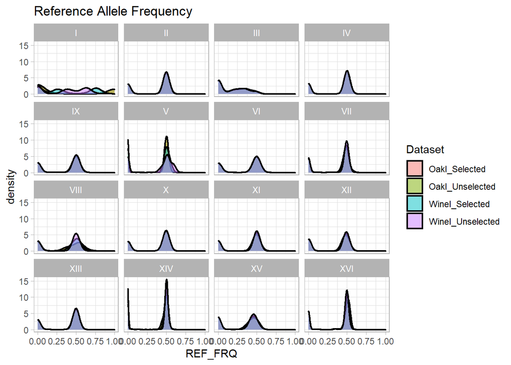

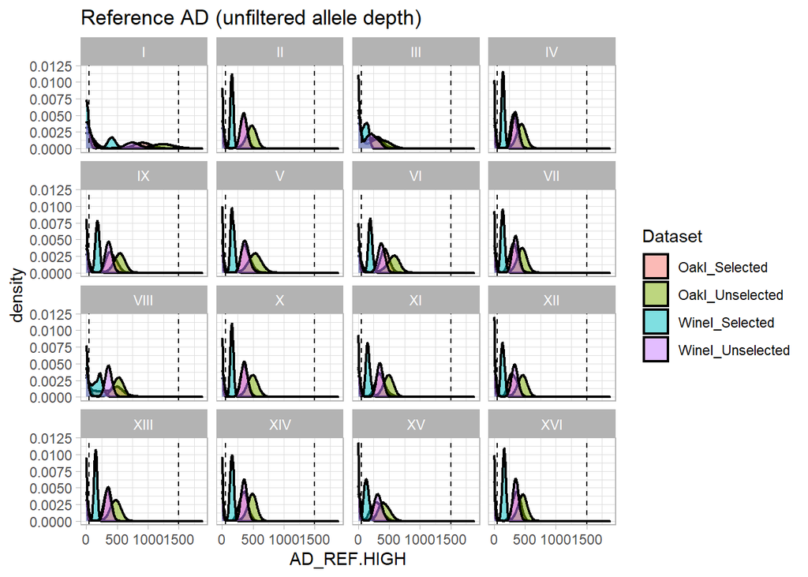

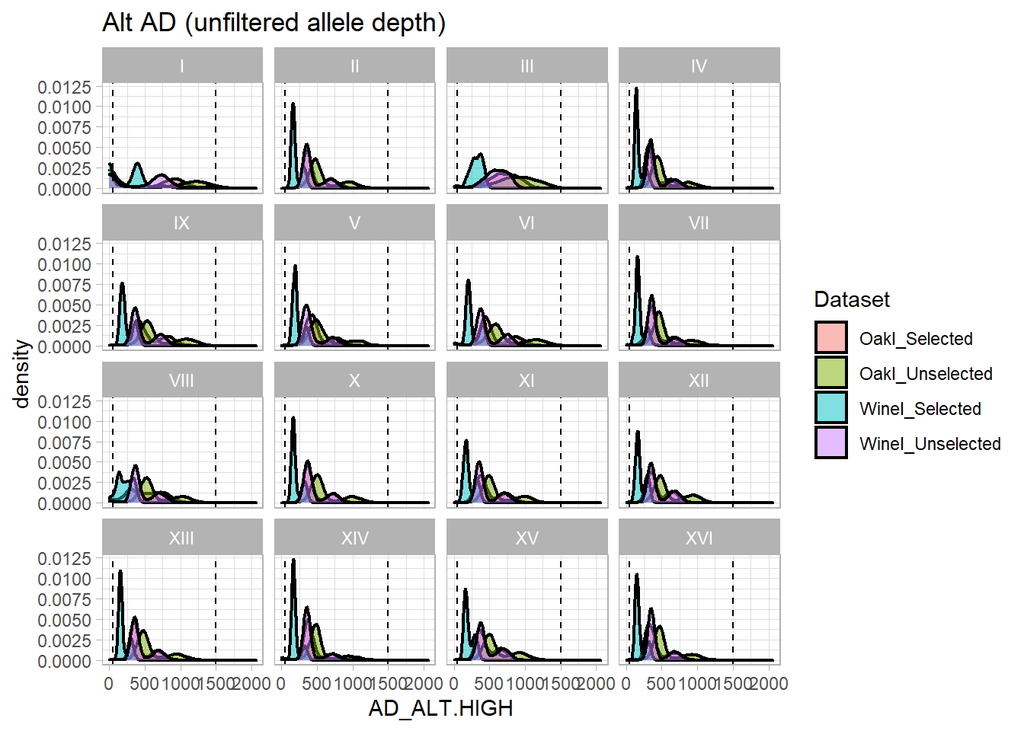

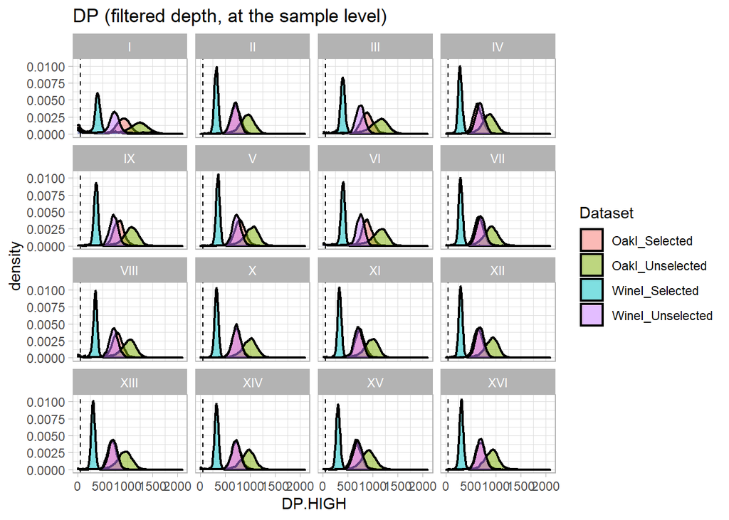

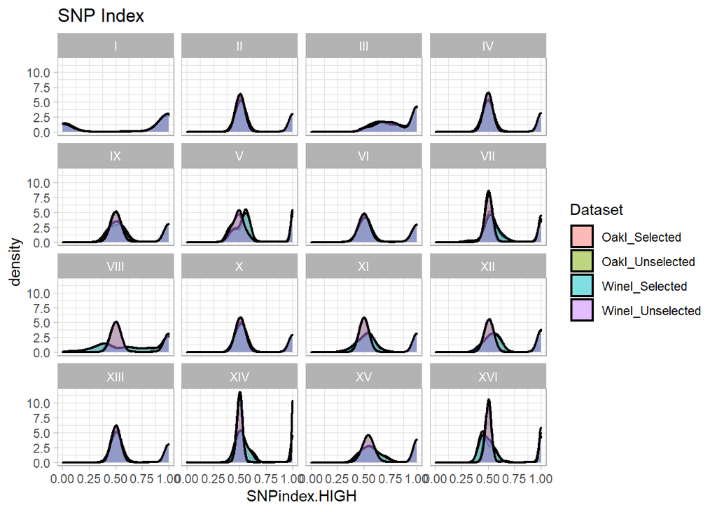

### Extracting Stats for Telomeres

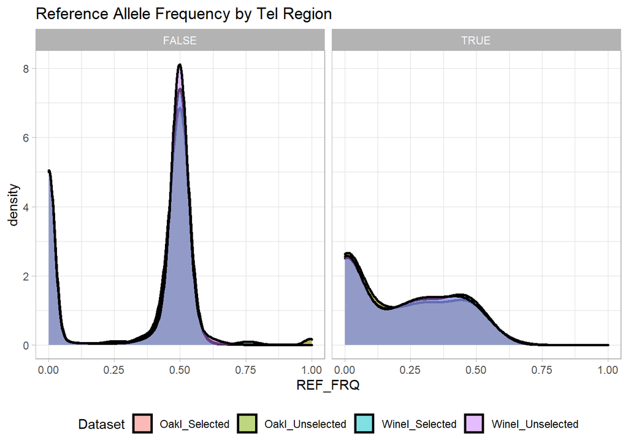

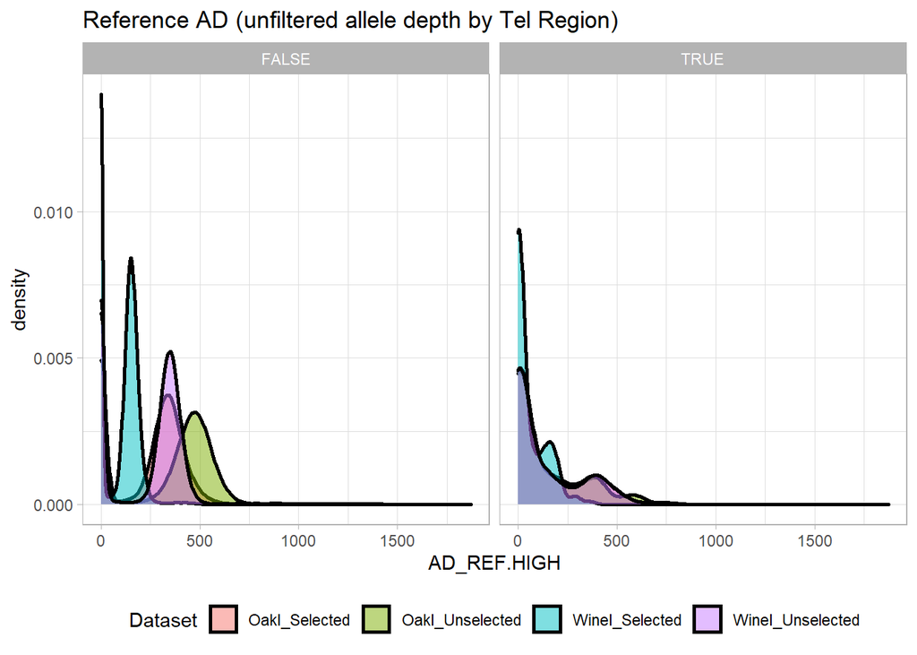

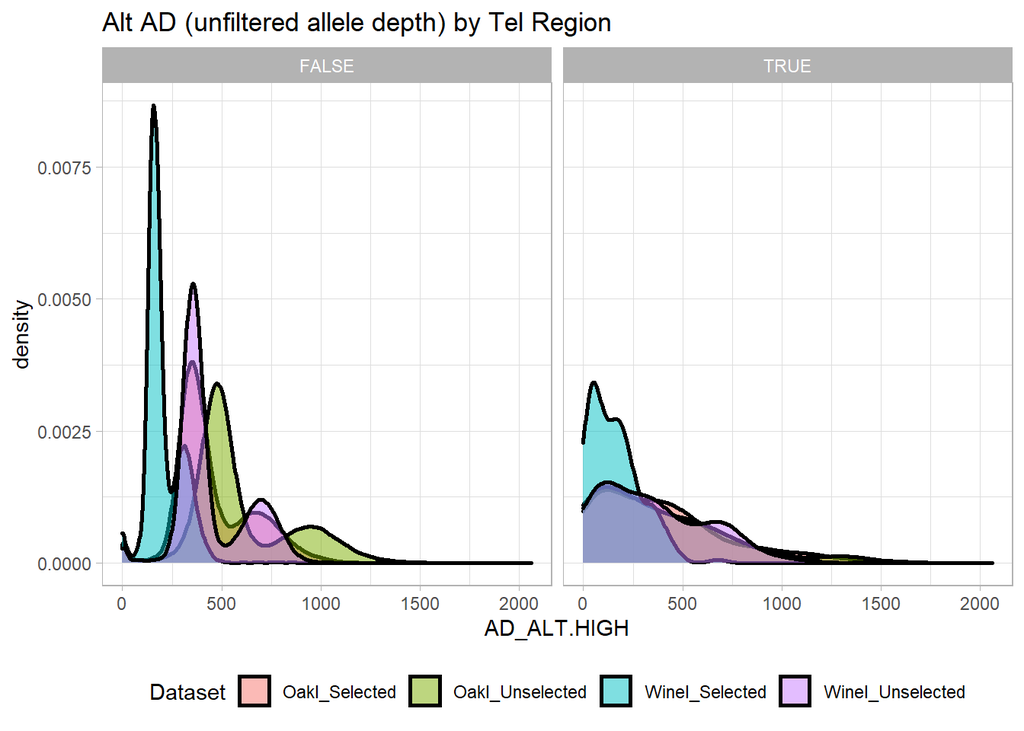

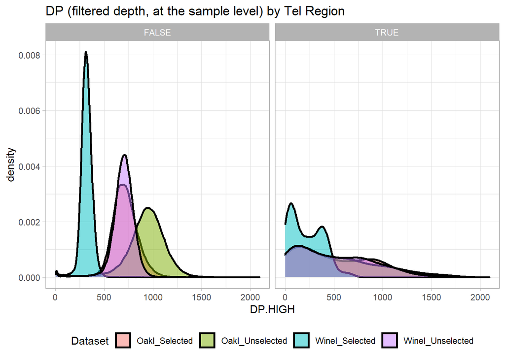

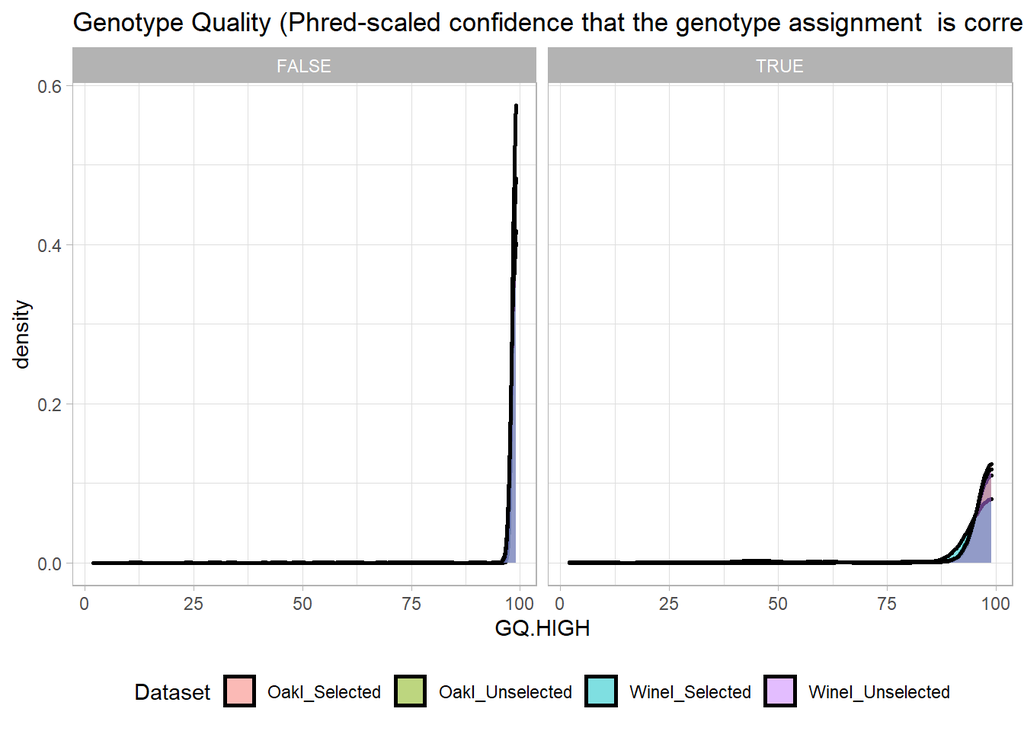

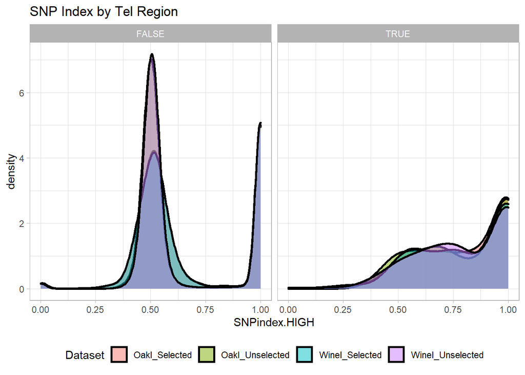

${\Delta}$SNP: the difference of the low value bulk SNP-index from the high value bulk SNP-index

## Run All Data Through Functions

Raw data is defined as a vcf.output.table, downloaded from $SCRATCH/Sequencing/* where that iteration of the sequencing pipeline has been stored. Naming of these variables and the pipeline itself is stored in READ.ME in each folder.

```r
#rawData = "C:\\Users\\cassa\\OneDrive\\Documents\\R_SiegalLab\\SequencingPractice\\Data\\TelTrimmed_mergedCuSO4.REF.SortedCat.vcf.output.table"

HNG %>% filter(CHROM != "NC_001133.9") -> HNGc

SAUA <- PipelineFunc(HighBulk = "SelectedA", LowBulk = "UnselectedA", rawData = rawData, BulkSize = c(2.1e9, 1.26e10), Chroms = unique(HNGc$CHROM))
SCUC <- PipelineFunc(HighBulk = "SelectedC", LowBulk = "UnselectedC", rawData = rawData, BulkSize = c(1.8e9, 1.3e10), Chroms = unique(HNGc$CHROM))
Selected <- PipelineFunc(HighBulk = "SelectedA", LowBulk = "SelectedC", rawData = rawData, BulkSize = c(2.1e9, 1.8e9), Chroms = unique(HNGc$CHROM))
Unselected <- PipelineFunc(HighBulk = "UnselectedA", LowBulk = "UnselectedC", rawData = rawData, BulkSize = c(1.3e10), Chroms = unique(HNGc$CHROM))
```

### Traditional BSA (Selected vs Unselected)

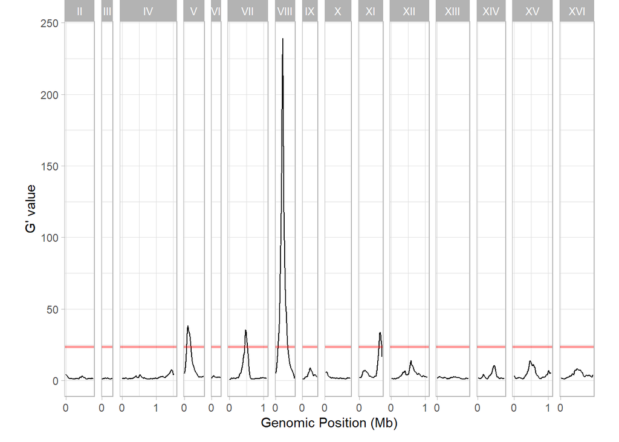

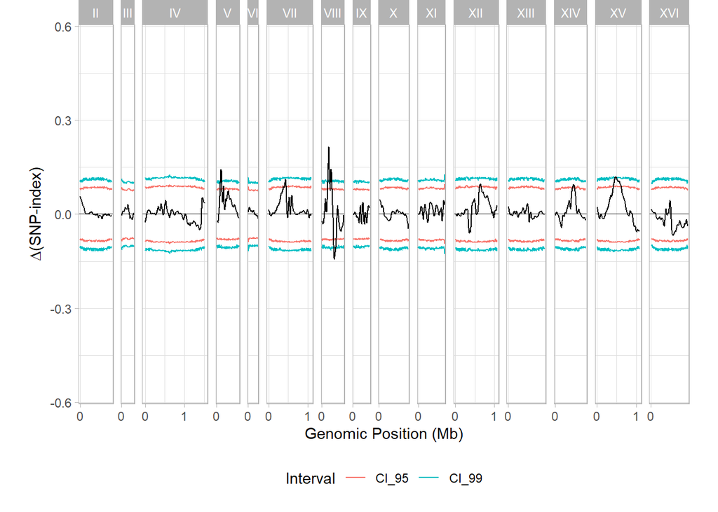

```r
plotallfunc(SAUA, HighBulk = "SelectedA", LowBulk = "UnselectedA")
```

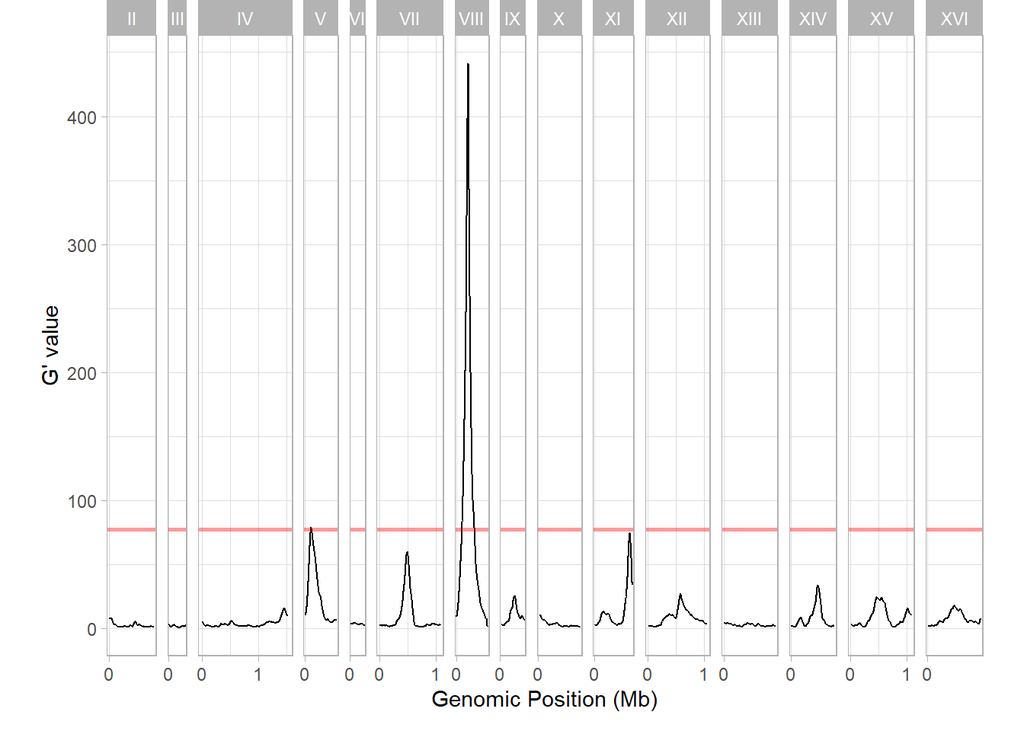

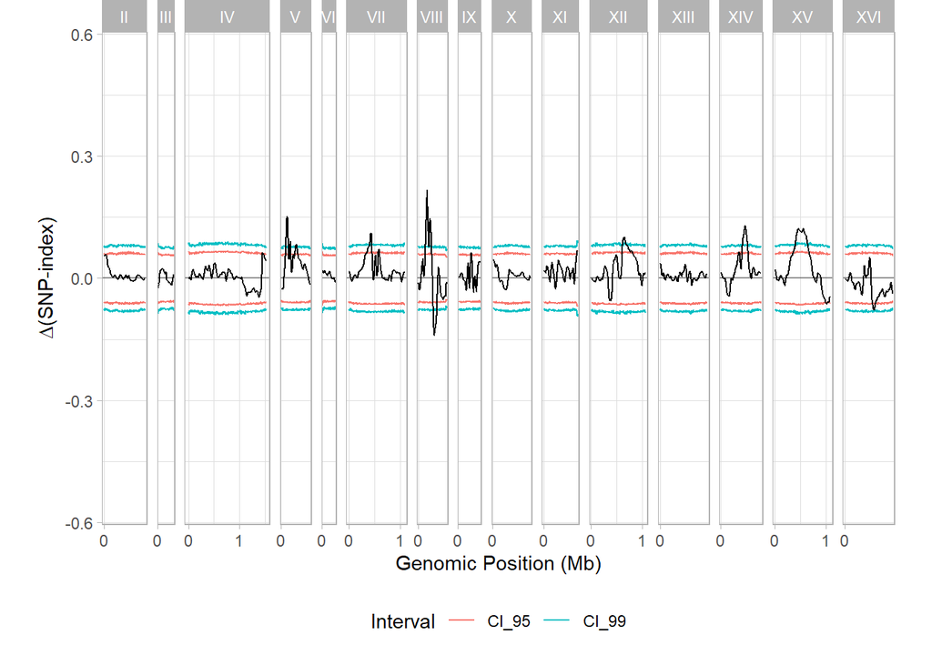

```r
plotallfunc(SCUC, HighBulk = "SelectedC", LowBulk = "UnselectedC")
```

### Unselected Bulks

These two bulks should only differ at Chr I since that is the fixed chromosome; all other loci should segregate evenly and be at approximately 50/50 frequency. One potential issue is in variation in alignment caused by the background of the fixed chromosome; those that are consistent between the unselected bulk comparison (null) and the selected bulk comparison (epistasis, below), should be removed for this reason.

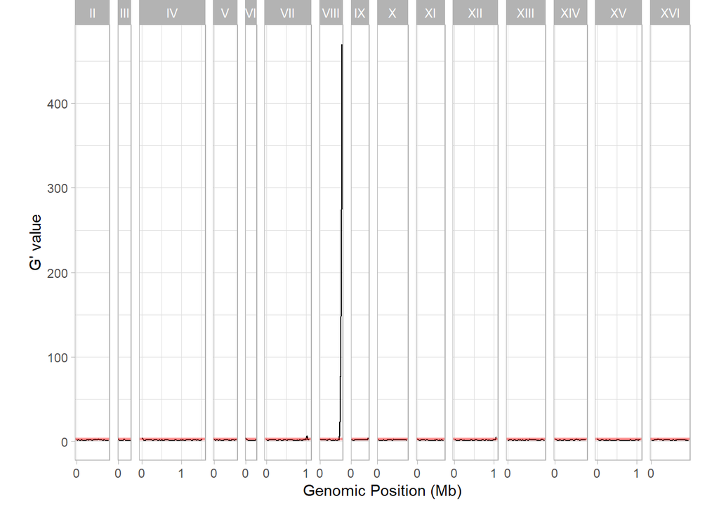

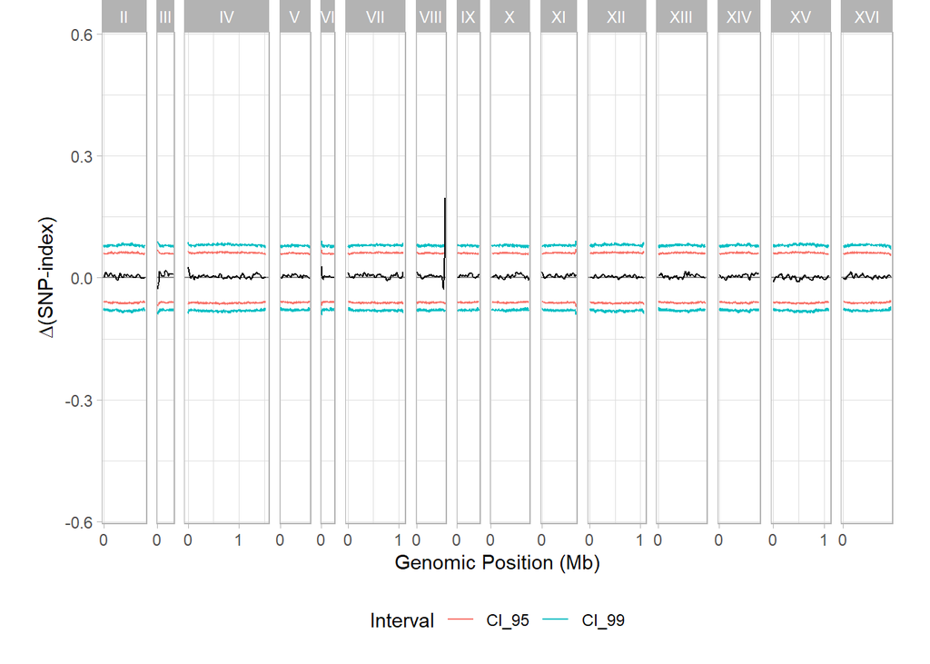

```r
# plotallfunc(subset(Unselected, Gprime < 50), HighBulk = "UnselectedC", LowBulk = "UnselectedA")
plotallfunc(Unselected, HighBulk = "UnselectedC", LowBulk = "UnselectedA")
```

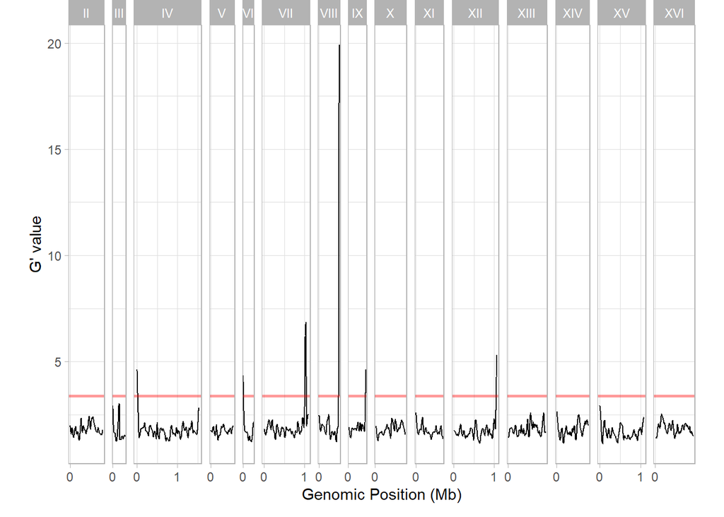

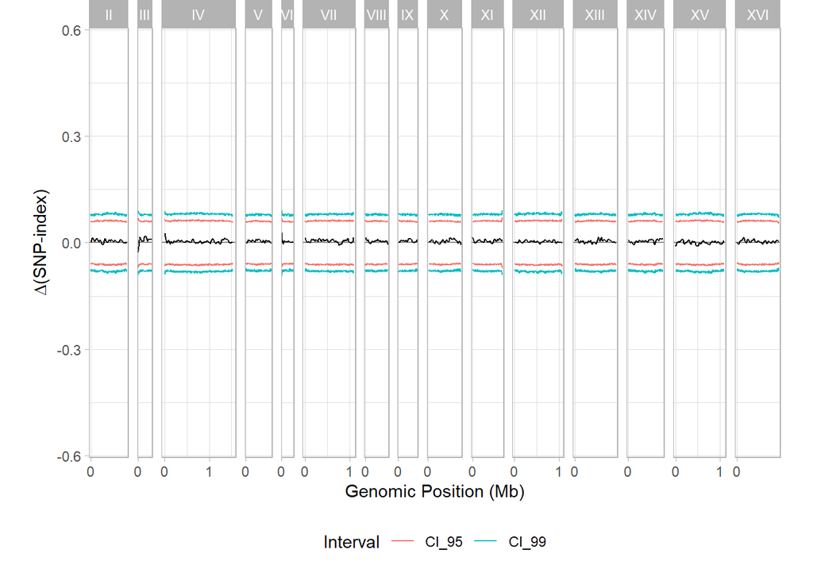

```r
plotallfunc(subset(Unselected, Gprime < 20), HighBulk = "UnselectedC", LowBulk = "UnselectedA")
```

### Selected Bulks: Epistasis with Chromosome I

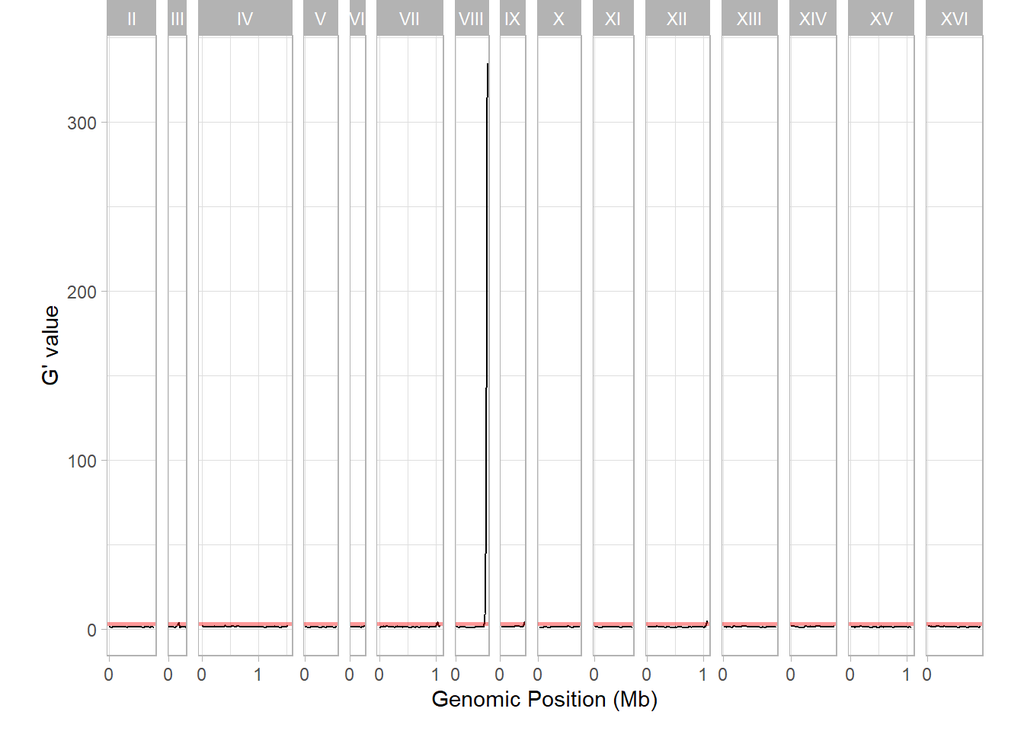

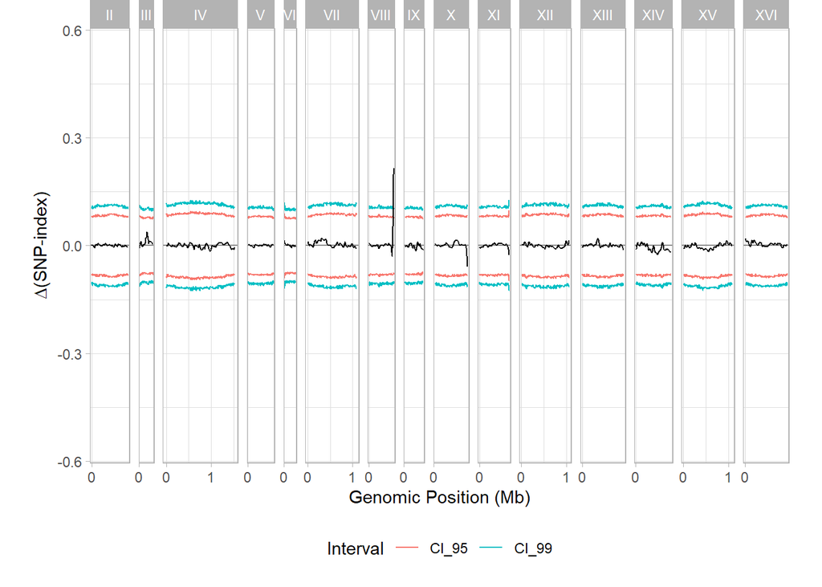

```r
#plotallfunc(subset(Selected, Gprime < 50), HighBulk = "SelectedA", LowBulk = "SelectedC")

plotallfunc(Selected, HighBulk = "SelectedA", LowBulk = "SelectedC")
```

### Testing Epistasis Data Chr. III

There looks to be one small peak on Chr III in the comparison of Selected bulks that does not appear between the Unselected bulks. To better resolve this peak, I ran `PipelineFunc()` on that single chromosome with a window size of 1e4, and then identified the peak.

```r
plot.deltasnp <- plotQTLStatsCB(SNPset = Selected_3, var = "deltaSNP", plotIntervals = TRUE)


ggplot(data = Selected_3, aes(x = POS, y = Gprime)) + geom_line(size = 1, color = CBchromPalette[2]) +
  scale_x_continuous(breaks = seq(from = 0, to = max(Selected_3$POS),
                                  by = 10^(floor(log10(max(Selected_3$POS))))),
                    # labels = format_genomic(),
                    name = "Genomic Position (Mb)") +
  theme(plot.margin = margin(b = 10, l = 20, r = 20, unit = "pt")) +
  guides(colour = "none") +
    geom_vline(xintercept = c(114385,114501), col = "gray", linetype = "dotted", size = 1) + #CEN3
  facet_grid(~CHROM, scales = "free_x", space = "free_x") + ggtitle("Selected, Chr III")
```

[output not shown]

### Identifying CUP1 gene on Chr VIII

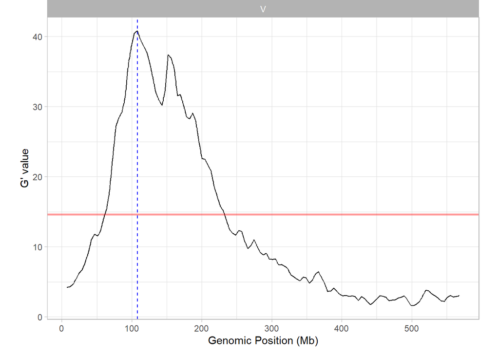

```r
# ggplot(data = Oak_8, aes(x = POS, y = Gprime, color = CHROM)) + geom_line(size = 1, color = CBchromPalette[7]) +
#   scale_x_continuous(breaks = seq(from = 0, to = max(Oak_8$POS),
#                                   by = 10^(floor(log10(max(Oak_8$POS))))),
#                     # labels = format_genomic(),
#                     name = "Genomic Position (Mb)") +
#   theme(plot.margin = margin(b = 10, l = 20, r = 20, unit = "pt")) +
#   guides(colour = "none") +
#     geom_vline(xintercept = 212535, linetype = "dashed", size = 1) + #CUP1 gene
#     geom_vline(xintercept = c(105586), col = "gray", linetype = "dotted", size = 1) + #CEN8
#   facet_grid(~CHROM, scales = "free_x", space = "free_x") + ggtitle("Oak Fixed, Chr VIII")


plotQTLStats(SNPset = Oak_5, var = "Gprime", plotThreshold = TRUE, q = 0.01) + geom_vline(xintercept = Oak_5$POS[Oak_5$Gprime == max(Oak_5$Gprime)], linetype = "dashed", color = "blue")
```

```r
Oak_5$POS[Oak_5$Gprime == max(Oak_5$Gprime)] #TIM9
```

```
## [1] 107929
```

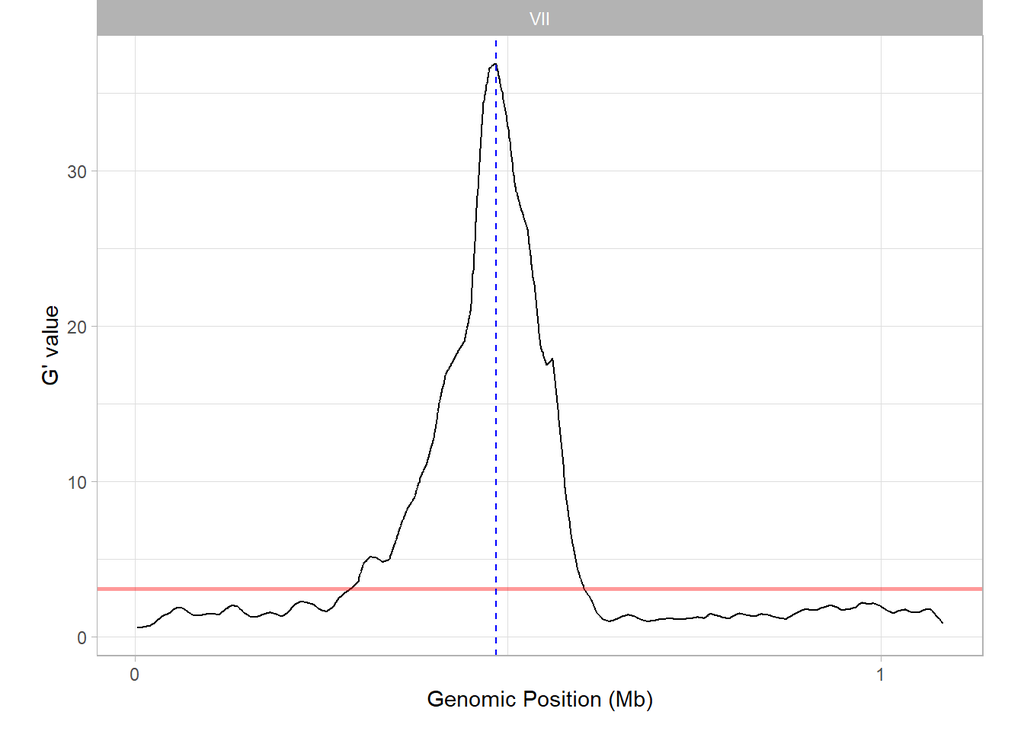

```r
plotQTLStats(SNPset = Oak_7, var = "Gprime", plotThreshold = TRUE, q = 0.01) + geom_vline(xintercept = Oak_7$POS[Oak_7$Gprime == max(Oak_7$Gprime)], linetype = "dashed", color = "blue")
```

```r
Oak_7$POS[Oak_7$Gprime == max(Oak_7$Gprime)] #YGL007C-A
```

```
## [1] 484209
```

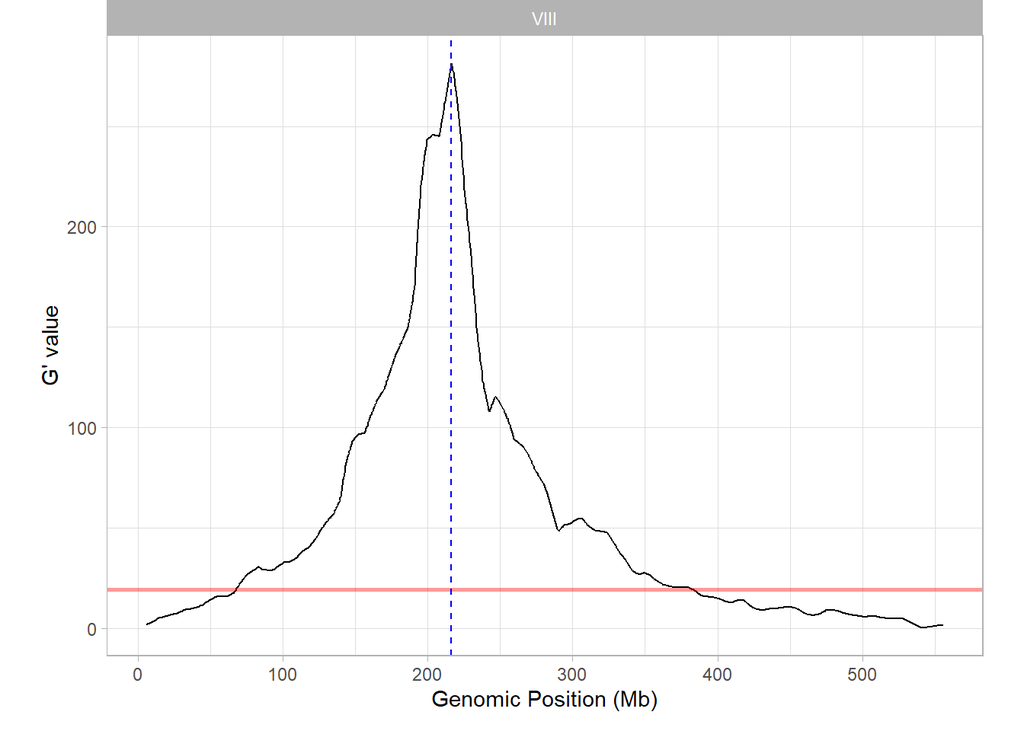

```r
plotQTLStats(SNPset = Oak_8, var = "Gprime", plotThreshold = TRUE, q = 0.01) + geom_vline(xintercept = Oak_8$POS[Oak_8$Gprime == max(Oak_8$Gprime)], linetype = "dashed", color = "blue")
```

```r
Oak_8$POS[Oak_8$Gprime == max(Oak_8$Gprime)] #CUP1
```

```
## [1] 216338
```

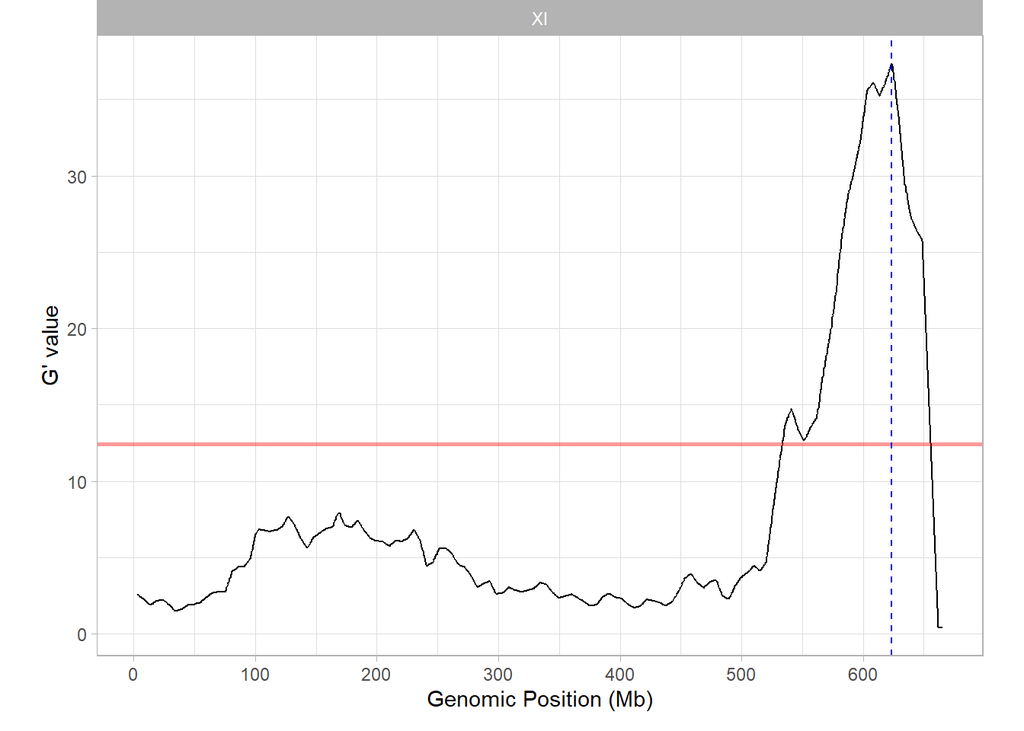

```r
plotQTLStats(SNPset = Oak_11, var = "Gprime", plotThreshold = TRUE, q = 0.01) + geom_vline(xintercept = Oak_11$POS[Oak_11$Gprime == max(Oak_11$Gprime)], linetype = "dashed", color = "blue")
```

```r
Oak_11$POS[Oak_11$Gprime == max(Oak_11$Gprime)] #PXL1
```

```
## [1] 623494
```

```r
## Calculating where the slope changes

library(pracma)

value <- Oak_8$Gprime
plot(value)
value_prime <- pracma::gradient(value, h1 = 2)
plot(value_prime)

ggplot(data = Oak_8, aes(x = POS, y = Gprime, color = CHROM)) + geom_line(size = 1, color = CBchromPalette[7]) +
  scale_x_continuous(breaks = seq(from = 0, to = max(Oak_8$POS),
                                  by = 10^(floor(log10(max(Oak_8$POS))))),
                    # labels = format_genomic(),
                    name = "Genomic Position (Mb)") +
  theme(plot.margin = margin(b = 10, l = 20, r = 20, unit = "pt")) +
  guides(colour = "none") +
    geom_vline(xintercept = 212535, linetype = "dashed", size = 1) + #CUP1 gene
    geom_vline(xintercept = c(105586), col = "gray", linetype = "dotted", size = 1) + #CEN8
    geom_vline(xintercept = Oak_8$POS[which(value_prime > 4)], col = "red") +
  facet_grid(~CHROM, scales = "free_x", space = "free_x") + ggtitle("Oak Fixed, Chr VIII")

Oak_8[which(value_prime > 4),] %>% select(NC_Chrom, POS, REF, ALT, Gprime)

211825-216311
```

[output not shown]

## Combining QTL Traces between Fixed Chromosome Populations

Because we care what is differentially identified between Wine-fixed and Oak-fixed experiments, I am overlaying the G’ scores of the classic experiments to compare:

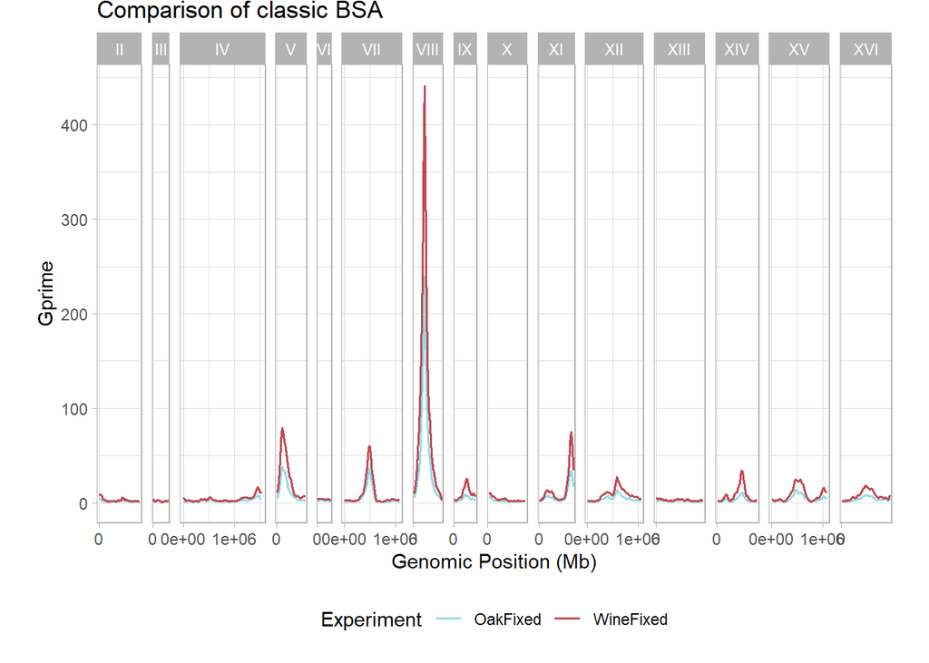

```r
# head(SAUA)
# head(SCUC)

SAUA %>% transmute(Experiment = "OakFixed", POS = POS, REF = REF, ALT = ALT, CHROM = CHROM,
                   nSNPs = nSNPs, tricubeDeltaSNP = tricubeDeltaSNP, G = G, Gprime = Gprime,
            pvalue = pvalue, negLog10Pval = negLog10Pval, qvalue = qvalue, minDP = minDP,
            tricupeDP = tricubeDP, CI_95 = CI_95, CI_99 = CI_99) -> OakFixed

SCUC %>% transmute(Experiment = "WineFixed", POS = POS, REF = REF, ALT = ALT, CHROM = CHROM,
                   nSNPs = nSNPs, tricubeDeltaSNP = tricubeDeltaSNP, G = G, Gprime = Gprime,
            pvalue = pvalue, negLog10Pval = negLog10Pval, qvalue = qvalue, minDP = minDP,
            tricupeDP = tricubeDP, CI_95 = CI_95, CI_99 = CI_99) -> WineFixed

BSAClassic <- rbind(OakFixed,WineFixed)

#plotQTLStatsCB(SNPset = BSAClassic, var = "Gprime", plotThreshold = TRUE, q = 0.01) #changed plotThreshold back to true to test

ggplot(data = BSAClassic, aes(x = POS, y = Gprime, color = Experiment)) + geom_line(size = 0.7) +
  scale_x_continuous(breaks = seq(from = 0, to = max(BSAClassic$POS),
                                  by = 10^(floor(log10(max(BSAClassic$POS))))),
                    # labels = format_genomic(),
                    name = "Genomic Position (Mb)") +
  theme(plot.margin = margin(b = 10, l = 20, r = 20, unit = "pt")) +
  #guides(colour = "none") +
    scale_colour_manual(values=CBchromPalette[6:5]) +
  facet_grid(~CHROM, scales = "free_x", space = "free_x") + ggtitle("Comparison of classic BSA")+ theme(legend.position = "bottom")
```

## Comparison of Nulls and Epistasis

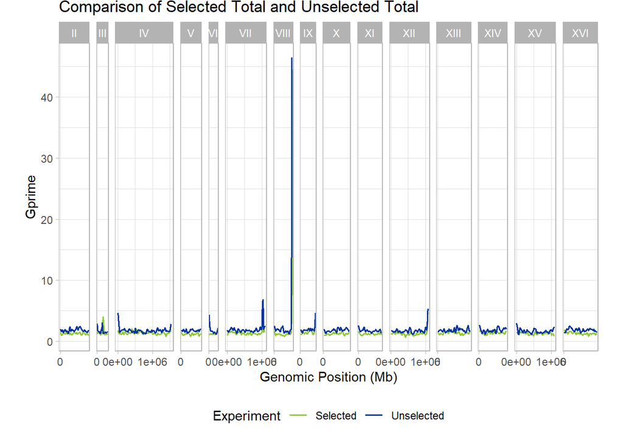

```r
Selected %>% transmute(Experiment = "Selected", POS = POS, REF = REF, ALT = ALT, CHROM = CHROM,
                   nSNPs = nSNPs, tricubeDeltaSNP = tricubeDeltaSNP, G = G, Gprime = Gprime,
            pvalue = pvalue, negLog10Pval = negLog10Pval, qvalue = qvalue, minDP = minDP,
            tricupeDP = tricubeDP, CI_95 = CI_95, CI_99 = CI_99) -> Selected_All

Unselected %>% transmute(Experiment = "Unselected", POS = POS, REF = REF, ALT = ALT, CHROM = CHROM,
                   nSNPs = nSNPs, tricubeDeltaSNP = tricubeDeltaSNP, G = G, Gprime = Gprime,
            pvalue = pvalue, negLog10Pval = negLog10Pval, qvalue = qvalue, minDP = minDP,
            tricupeDP = tricubeDP, CI_95 = CI_95, CI_99 = CI_99) -> Unselected_All

NullComparison <- rbind(Selected_All,Unselected_All)

#plotQTLStatsCB(SNPset = BSAClassic, var = "Gprime", plotThreshold = TRUE, q = 0.01) #changed plotThreshold back to true to test

ggplot(data = subset(NullComparison, Gprime < 50), aes(x = POS, y = Gprime, color = Experiment)) + geom_line(size = 0.7) +
  scale_x_continuous(breaks = seq(from = 0, to = max(BSAClassic$POS),
                                  by = 10^(floor(log10(max(BSAClassic$POS))))),
                    # labels = format_genomic(),
                    name = "Genomic Position (Mb)") +
  theme(plot.margin = margin(b = 10, l = 20, r = 20, unit = "pt")) +
  #guides(colour = "none") +
    scale_colour_manual(values=CBchromPalette[c(8,10)]) +
  facet_grid(~CHROM, scales = "free_x", space = "free_x") + ggtitle("Comparison of Selected Total and Unselected Total")+ theme(legend.position = "bottom")
```

#### Chr XVI Peak

```r
#Pulling out Chr XVI for epistasis
Selected_16 <- PipelineFunc(HighBulk = "SelectedA", LowBulk = "SelectedC",
                           rawData = rawData,
                           Chroms = "NC_001148.4", windowSize = 1e4)
```

```
## Removing the following chromosomes: NC_001133.9, NC_001134.8, NC_001135.5, NC_001136.10, NC_001137.3, NC_001138.5, NC_001139.9, NC_001140.6, NC_001141.2, NC_001142.9, NC_001143.9, NC_001144.5, NC_001145.3, NC_001146.8, NC_001147.6, NC_001224.1
```

```
## Filtering by reference allele frequency: 0.1 <= REF_FRQ <= 0.9
```

```
## ...Filtered 1116 SNPs
```

```
## Original SNP number: 4843, Filtered: 1116, Remaining: 3727
```

```
## Counting SNPs in each window...
```

```
## Calculating tricube smoothed delta SNP index...
```

```
## Calculating G and G' statistics...
```

```
## Using deltaSNP-index to filter outlier regions with a threshold of 0.1
```

```
## Estimating the mode of a trimmed G prime set using the 'modeest' package...
```

```
## Calculating p-values...
```

```
## Counting SNPs in each window...
```

```
## Calculating tricube smoothed delta SNP index...
```

```
## Returning the following two sided confidence intervals: 95, 99
```

```
## Variable 'depth' not defined, using min and max depth from data: 4-495
```

```
## Assuming bulks selected from F2 population, with 1000 individuals per bulk.
```

```
## The 'bulkSize' argument is of length 1, setting number of individuals in both bulks to: 1000
```

```
## Simulating 10000 SNPs with reads at each depth: 4-495
```

```
## Keeping SNPs with >= 0.3 SNP-index in both simulated bulks
```

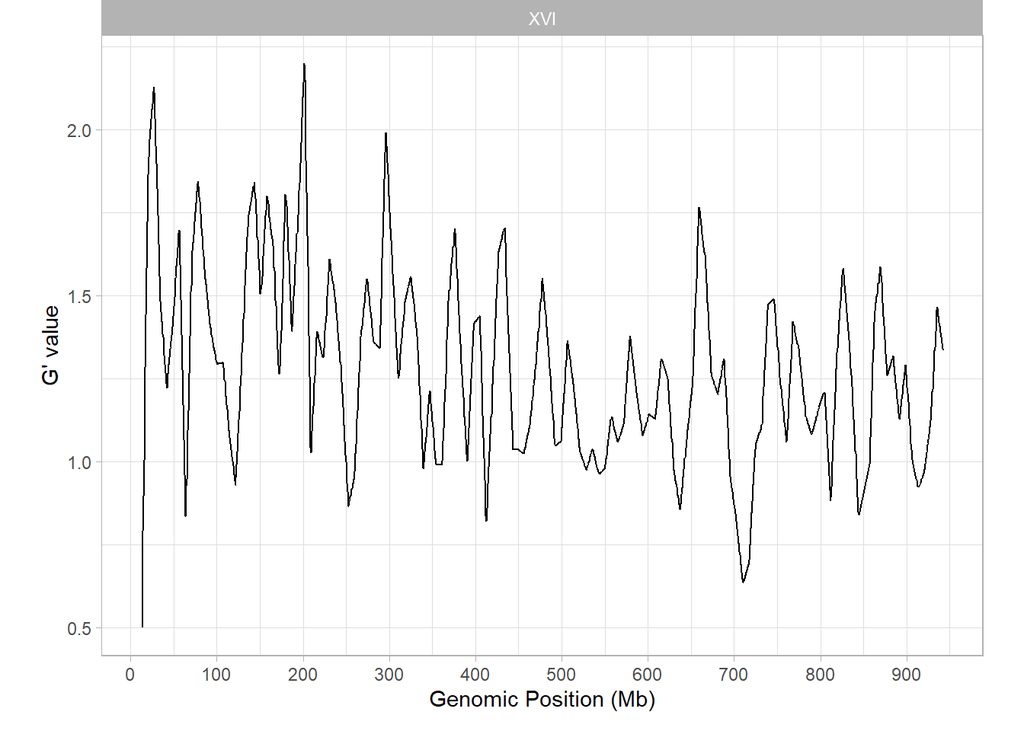

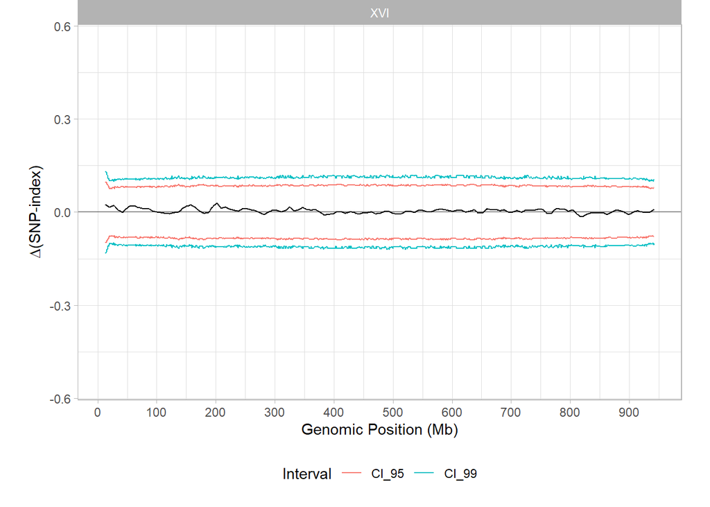

```r
plotallfunc(Selected_16, HighBulk = "SelectedA", LowBulk = "SelectedC")
```